# Machine Learning II. Trabajo de evaluación. Temas: Boosting, Aprendizaje Supervisado Secuencial, Selección de Atributos

Jerónimo Carranza Carranza

30 de junio de 2017

# 1 Boosting

1. A partir de la base de datos *spam* de la librería *kernlab*, construya una muestra de aprendizaje aleatoria formado por el 70% de las instancias, y una muestra de validación formada por el 30% restante.
2. Construya un modelo boosting a partir de la muestra de aprendizaje generada para pronosticar la variable *type* a partir de las restantes variables (utilice la librería *adabag*)
3. Realice predicciones para la muestra de validación y obtenga la matriz de confusión y el porcentaje de observaciones mal clasificadas. Obtenga el margen de las observaciones de la muestra de validación y determine los índices correspondientes a las que han sido mal clasificadas
4. Utilizando validación cruzada con 10 pliegues, obtenga la matriz de confusión y el porcentaje de observaciones mal clasificadas.
5. Utilizando la función *train* de la librería *caret*, determine los parámetros óptimos dentro del siguiente conjunto:  
   mfinal ∈ {5,6,7,8,9,10}, maxdepth ∈ {1,2}, coeflearn ∈ {Breiman,Zhu}.  
   Como técnica de validación, utilizar validación cruzada con 3 pliegues.

## 1.1 Lectura de datos

```r
library(kernlab)
data(spam)

str(spam)
```

```
## 'data.frame':    4601 obs. of  58 variables:
##  $ make             : num  0 0.21 0.06 0 0 0 0 0 0.15 0.06 ...
##  $ address          : num  0.64 0.28 0 0 0 0 0 0 0 0.12 ...
##  $ all              : num  0.64 0.5 0.71 0 0 0 0 0 0.46 0.77 ...
##  $ num3d            : num  0 0 0 0 0 0 0 0 0 0 ...
##  $ our              : num  0.32 0.14 1.23 0.63 0.63 1.85 1.92 1.88 0.61 0.19 ...
##  $ over             : num  0 0.28 0.19 0 0 0 0 0 0 0.32 ...
##  $ remove           : num  0 0.21 0.19 0.31 0.31 0 0 0 0.3 0.38 ...
##  $ internet         : num  0 0.07 0.12 0.63 0.63 1.85 0 1.88 0 0 ...
##  $ order            : num  0 0 0.64 0.31 0.31 0 0 0 0.92 0.06 ...
##  $ mail             : num  0 0.94 0.25 0.63 0.63 0 0.64 0 0.76 0 ...
##  $ receive          : num  0 0.21 0.38 0.31 0.31 0 0.96 0 0.76 0 ...
##  $ will             : num  0.64 0.79 0.45 0.31 0.31 0 1.28 0 0.92 0.64 ...
##  $ people           : num  0 0.65 0.12 0.31 0.31 0 0 0 0 0.25 ...
##  $ report           : num  0 0.21 0 0 0 0 0 0 0 0 ...
```

[output cut: 44 more lines]

```r
head(spam)
```

```
##   make address  all num3d  our over remove internet order mail receive
## 1 0.00    0.64 0.64     0 0.32 0.00   0.00     0.00  0.00 0.00    0.00
## 2 0.21    0.28 0.50     0 0.14 0.28   0.21     0.07  0.00 0.94    0.21
## 3 0.06    0.00 0.71     0 1.23 0.19   0.19     0.12  0.64 0.25    0.38
## 4 0.00    0.00 0.00     0 0.63 0.00   0.31     0.63  0.31 0.63    0.31
## 5 0.00    0.00 0.00     0 0.63 0.00   0.31     0.63  0.31 0.63    0.31
## 6 0.00    0.00 0.00     0 1.85 0.00   0.00     1.85  0.00 0.00    0.00
##   will people report addresses free business email  you credit your font
## 1 0.64   0.00   0.00      0.00 0.32     0.00  1.29 1.93   0.00 0.96    0
## 2 0.79   0.65   0.21      0.14 0.14     0.07  0.28 3.47   0.00 1.59    0
## 3 0.45   0.12   0.00      1.75 0.06     0.06  1.03 1.36   0.32 0.51    0
## 4 0.31   0.31   0.00      0.00 0.31     0.00  0.00 3.18   0.00 0.31    0
## 5 0.31   0.31   0.00      0.00 0.31     0.00  0.00 3.18   0.00 0.31    0
## 6 0.00   0.00   0.00      0.00 0.00     0.00  0.00 0.00   0.00 0.00    0
##   num000 money hp hpl george num650 lab labs telnet num857 data num415
```

[output cut: 34 more lines]

Conjunto con 4601 casos y 58 variables, todas menos una de tipo numérico y una de tipo factor, *type*, dicotómico, es la variable objetivo, que identifica si el correo es spam o no.

## 1.2 Resumen de datos

```r
summary(spam)
```

```
##       make           address            all             num3d
##  Min.   :0.0000   Min.   : 0.000   Min.   :0.0000   Min.   : 0.00000
##  1st Qu.:0.0000   1st Qu.: 0.000   1st Qu.:0.0000   1st Qu.: 0.00000
##  Median :0.0000   Median : 0.000   Median :0.0000   Median : 0.00000
##  Mean   :0.1046   Mean   : 0.213   Mean   :0.2807   Mean   : 0.06542
##  3rd Qu.:0.0000   3rd Qu.: 0.000   3rd Qu.:0.4200   3rd Qu.: 0.00000
##  Max.   :4.5400   Max.   :14.280   Max.   :5.1000   Max.   :42.81000
##       our               over            remove          internet
##  Min.   : 0.0000   Min.   :0.0000   Min.   :0.0000   Min.   : 0.0000
##  1st Qu.: 0.0000   1st Qu.:0.0000   1st Qu.:0.0000   1st Qu.: 0.0000
##  Median : 0.0000   Median :0.0000   Median :0.0000   Median : 0.0000
##  Mean   : 0.3122   Mean   :0.0959   Mean   :0.1142   Mean   : 0.1053
##  3rd Qu.: 0.3800   3rd Qu.:0.0000   3rd Qu.:0.0000   3rd Qu.: 0.0000
##  Max.   :10.0000   Max.   :5.8800   Max.   :7.2700   Max.   :11.1100
##      order              mail            receive             will
##  Min.   :0.00000   Min.   : 0.0000   Min.   :0.00000   Min.   :0.0000
##  1st Qu.:0.00000   1st Qu.: 0.0000   1st Qu.:0.00000   1st Qu.:0.0000
##  Median :0.00000   Median : 0.0000   Median :0.00000   Median :0.1000
##  Mean   :0.09007   Mean   : 0.2394   Mean   :0.05982   Mean   :0.5417
##  3rd Qu.:0.00000   3rd Qu.: 0.1600   3rd Qu.:0.00000   3rd Qu.:0.8000
##  Max.   :5.26000   Max.   :18.1800   Max.   :2.61000   Max.   :9.6700
##      people            report           addresses           free
##  Min.   :0.00000   Min.   : 0.00000   Min.   :0.0000   Min.   : 0.0000
##  1st Qu.:0.00000   1st Qu.: 0.00000   1st Qu.:0.0000   1st Qu.: 0.0000
##  Median :0.00000   Median : 0.00000   Median :0.0000   Median : 0.0000
##  Mean   :0.09393   Mean   : 0.05863   Mean   :0.0492   Mean   : 0.2488
##  3rd Qu.:0.00000   3rd Qu.: 0.00000   3rd Qu.:0.0000   3rd Qu.: 0.1000
##  Max.   :5.55000   Max.   :10.00000   Max.   :4.4100   Max.   :20.0000
##     business          email             you             credit
##  Min.   :0.0000   Min.   :0.0000   Min.   : 0.000   Min.   : 0.00000
##  1st Qu.:0.0000   1st Qu.:0.0000   1st Qu.: 0.000   1st Qu.: 0.00000
##  Median :0.0000   Median :0.0000   Median : 1.310   Median : 0.00000
##  Mean   :0.1426   Mean   :0.1847   Mean   : 1.662   Mean   : 0.08558
##  3rd Qu.:0.0000   3rd Qu.:0.0000   3rd Qu.: 2.640   3rd Qu.: 0.00000
##  Max.   :7.1400   Max.   :9.0900   Max.   :18.750   Max.   :18.18000
##       your              font             num000           money
##  Min.   : 0.0000   Min.   : 0.0000   Min.   :0.0000   Min.   : 0.00000
##  1st Qu.: 0.0000   1st Qu.: 0.0000   1st Qu.:0.0000   1st Qu.: 0.00000
##  Median : 0.2200   Median : 0.0000   Median :0.0000   Median : 0.00000
##  Mean   : 0.8098   Mean   : 0.1212   Mean   :0.1016   Mean   : 0.09427
```

[output cut: 50 more lines]

```
##  Max.   :4.38500   Max.   :9.752    Max.   :4.08100   Max.   :32.4780
##    charDollar         charHash          capitalAve        capitalLong
##  Min.   :0.00000   Min.   : 0.00000   Min.   :   1.000   Min.   :   1.00
##  1st Qu.:0.00000   1st Qu.: 0.00000   1st Qu.:   1.588   1st Qu.:   6.00
##  Median :0.00000   Median : 0.00000   Median :   2.276   Median :  15.00
##  Mean   :0.07581   Mean   : 0.04424   Mean   :   5.191   Mean   :  52.17
##  3rd Qu.:0.05200   3rd Qu.: 0.00000   3rd Qu.:   3.706   3rd Qu.:  43.00
##  Max.   :6.00300   Max.   :19.82900   Max.   :1102.500   Max.   :9989.00
##   capitalTotal          type
##  Min.   :    1.0   nonspam:2788
##  1st Qu.:   35.0   spam   :1813
##  Median :   95.0
##  Mean   :  283.3
##  3rd Qu.:  266.0
##  Max.   :15841.0
```

## 1.3 Conjuntos de entrenamiento y validación

```r
set.seed(12345)
n = nrow(spam)
ind = sample(n, n*0.7)

SPAMtrain = spam[ind,]
SPAMval = spam[-ind,]

head(SPAMtrain)
```

```
##      make address all num3d  our over remove internet order mail receive
## 3317 0.00       0 0.0     0 0.27 0.00      0     0.55   0.0 0.55       0
## 4029 0.89       0 0.0     0 0.89 0.89      0     0.00   0.0 0.00       0
## 3500 0.00       0 0.0     0 0.00 0.00      0     0.00   0.0 1.96       0
## 4075 0.00       0 0.0     0 0.00 0.00      0     0.00   0.0 0.00       0
## 2099 0.00       0 0.2     0 0.60 0.20      0     0.00   0.1 0.00       0
## 765  0.00       0 0.0     0 0.94 0.00      0     0.00   0.0 0.94       0
##      will people report addresses free business email  you credit your
## 3317 0.55      0      0         0    0      0.0  0.00 0.00      0 0.00
## 4029 0.00      0      0         0    0      0.0  0.00 2.67      0 1.78
## 3500 0.00      0      0         0    0      0.0  1.96 1.96      0 0.00
## 4075 0.00      0      0         0    0      0.0  0.00 2.24      0 0.00
## 2099 0.50      0      0         0    0      0.1  0.00 0.20      0 0.00
## 765  0.00      0      0         0    0      0.0  0.00 2.83      0 2.83
##      font num000 money   hp  hpl george num650  lab labs telnet num857
```

[output cut: 34 more lines]

```r
head(SPAMval)
```

```
##    make address  all num3d  our over remove internet order mail receive
## 4  0.00    0.00 0.00     0 0.63 0.00   0.31     0.63  0.31 0.63    0.31
## 7  0.00    0.00 0.00     0 1.92 0.00   0.00     0.00  0.00 0.64    0.96
## 10 0.06    0.12 0.77     0 0.19 0.32   0.38     0.00  0.06 0.00    0.00
## 12 0.00    0.00 0.25     0 0.38 0.25   0.25     0.00  0.00 0.00    0.12
## 13 0.00    0.69 0.34     0 0.34 0.00   0.00     0.00  0.00 0.00    0.00
## 16 0.00    0.42 0.42     0 1.27 0.00   0.42     0.00  0.00 1.27    0.00
##    will people report addresses free business email  you credit your font
## 4  0.31   0.31      0      0.00 0.31        0  0.00 3.18   0.00 0.31    0
## 7  1.28   0.00      0      0.00 0.96        0  0.32 3.85   0.00 0.64    0
## 10 0.64   0.25      0      0.12 0.00        0  0.12 1.67   0.06 0.71    0
## 12 0.12   0.12      0      0.00 0.00        0  0.00 1.16   0.00 0.77    0
## 13 0.69   0.00      0      0.00 0.34        0  1.39 2.09   0.00 1.04    0
## 16 0.00   0.00      0      0.00 1.27        0  0.00 1.70   0.42 1.27    0
##    num000 money hp hpl george num650 lab labs telnet num857 data num415
```

[output cut: 34 more lines]

## 1.4 Clasificador boosting

```r
library(adabag)
spam.adaboost = boosting(type~., data=SPAMtrain,
                         mfinal=10, control = rpart.control(maxdepth =1))
```

```r
# Importancia de variables predictoras
sort(spam.adaboost$importance,decreasing = TRUE)
```

```
##        charDollar   charExclamation                hp            remove
##         25.213140         19.499126         13.116177         10.307907
##              free        capitalAve              your            george
##          9.842162          6.657660          6.318483          5.776244
##             money           address         addresses               all
##          3.269100          0.000000          0.000000          0.000000
##          business       capitalLong      capitalTotal          charHash
##          0.000000          0.000000          0.000000          0.000000
##  charRoundbracket     charSemicolon charSquarebracket        conference
##          0.000000          0.000000          0.000000          0.000000
##            credit                cs              data            direct
##          0.000000          0.000000          0.000000          0.000000
##               edu             email              font               hpl
##          0.000000          0.000000          0.000000          0.000000
##          internet               lab              labs              mail
##          0.000000          0.000000          0.000000          0.000000
##              make           meeting            num000           num1999
##          0.000000          0.000000          0.000000          0.000000
##             num3d            num415            num650             num85
##          0.000000          0.000000          0.000000          0.000000
##            num857             order          original               our
##          0.000000          0.000000          0.000000          0.000000
##              over             parts            people                pm
##          0.000000          0.000000          0.000000          0.000000
##           project                re           receive            report
##          0.000000          0.000000          0.000000          0.000000
##             table        technology            telnet              will
##          0.000000          0.000000          0.000000          0.000000
##               you
##          0.000000
```

## 1.5 Predicciones

```r
pred.spam.adaboost = predict(object=spam.adaboost,newdata=SPAMval)

# Probabilidades de nospam(1) y spam(2) para cada caso de validación, 50 primeros
head(pred.spam.adaboost$prob, 50)
```

```
##             [,1]      [,2]
##  [1,] 0.31979412 0.6802059
##  [2,] 0.26025537 0.7397446
##  [3,] 0.26194366 0.7380563
##  [4,] 0.42495167 0.5750483
##  [5,] 0.33262162 0.6673784
##  [6,] 0.00000000 1.0000000
##  [7,] 0.36278152 0.6372185
##  [8,] 0.60025679 0.3997432
##  [9,] 0.52578953 0.4742105
## [10,] 0.06746005 0.9325400
## [11,] 0.41043588 0.5895641
## [12,] 0.42326338 0.5767366
## [13,] 0.00000000 1.0000000
## [14,] 0.42326338 0.5767366
```

[output cut: 36 more lines]

```r
# Clase predicha en cada caso, sólo los 50 primeros
head(pred.spam.adaboost$class,50)
```

```
##  [1] "spam"    "spam"    "spam"    "spam"    "spam"    "spam"    "spam"
##  [8] "nonspam" "nonspam" "spam"    "spam"    "spam"    "spam"    "spam"
## [15] "spam"    "spam"    "spam"    "spam"    "spam"    "spam"    "spam"
## [22] "spam"    "spam"    "nonspam" "nonspam" "spam"    "spam"    "spam"
## [29] "spam"    "spam"    "spam"    "spam"    "spam"    "spam"    "spam"
## [36] "nonspam" "spam"    "spam"    "spam"    "spam"    "spam"    "spam"
## [43] "spam"    "nonspam" "spam"    "spam"    "nonspam" "nonspam" "spam"
## [50] "spam"
```

## 1.6 Matriz de confusión

```r
pred.spam.adaboost$confusion
```

```
##                Observed Class
## Predicted Class nonspam spam
##         nonspam     794   98
##         spam         41  448
```

## 1.7 Porcentaje de clasificación incorrecta

```r
paste(round(100*pred.spam.adaboost$error,2),'%')
```

```
## [1] "10.07 %"
```

## 1.8 Márgenes de la muestra de validación

```r
(margin.val.spam.adaboost = margins(spam.adaboost,SPAMval))
```

```
## $margins
##    [1] -0.818716476 -0.821347879 -0.526529599 -0.526529599 -0.526529599
##    [6] -0.166593954  0.660772782  0.334756757 -0.526529599 -0.318845902
##   [11]  0.261993155  0.792316303 -0.686842100 -0.345246075  0.539063879
##   [16]  0.139931185  0.453089085 -0.526529599  0.660772782 -0.051579061
##   [21] -0.526529599  0.478744087 -0.318845902 -0.526529599 -0.686842100
##   [26]  0.865079905 -0.393175086 -0.632003802  0.795692877 -0.526529599
##   [31] -0.526529599  0.106364633  0.660772782 -0.527680865 -0.526529599
##   [36]  0.795692877 -0.232862585  0.093153440 -0.839687499  0.476112684
##   [41] -0.166593954 -0.839687499 -0.054210464 -0.546020485  0.792316303
##   [46] -0.054210464  0.331380182  0.466300278 -0.839687499 -0.526529599
##   [51] -0.526529599 -0.526529599  0.274436964 -0.322222476 -1.000000000
##   [56] -0.839687499 -0.054210464  0.334756757 -0.839687499  0.331380182
##   [61] -0.526529599  0.179128235 -0.526529599 -1.000000000 -0.183925806
##   [66]  0.660772782 -0.345246075  0.300837137 -0.658403975  0.479489258
```

[output cut: 266 more lines]

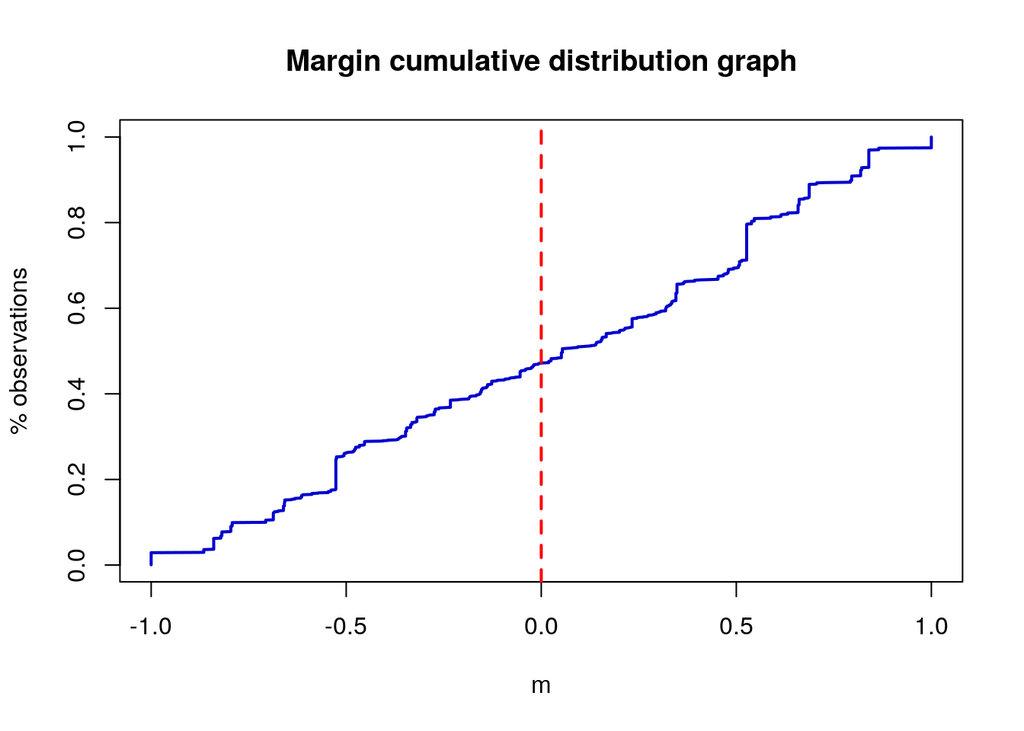

```r
plot.margins(margin.val.spam.adaboost)
```

## 1.9 Observaciones mal clasificadas

```r
SPAMvalPred = data.frame(SPAMval,'Pred'=pred.spam.adaboost$class)

SPAMvalPred[SPAMvalPred$type!=SPAMvalPred$Pred,c('type','Pred')]
```

```
##         type    Pred
## 34      spam nonspam
## 36      spam nonspam
## 105     spam nonspam
## 107     spam nonspam
## 139     spam nonspam
## 167     spam nonspam
## 174     spam nonspam
## 176     spam nonspam
## 207     spam nonspam
## 244     spam nonspam
## 287     spam nonspam
## 295     spam nonspam
## 302     spam nonspam
## 325     spam nonspam
```

[output cut: 125 more lines]

```r
as.integer(row.names(
  SPAMvalPred[SPAMvalPred$type!=SPAMvalPred$Pred,c('type','Pred')]
))
```

```
##   [1]   34   36  105  107  139  167  174  176  207  244  287  295  302  325
##  [15]  334  346  359  365  376  379  400  424  435  442  450  454  469  477
##  [29]  482  501  516  546  551  568  569  571  590  597  603  607  618  623
##  [43]  632  634  675  680  691  706  729  731  738  740  744  760  763  778
##  [57]  804  814  832  844  847  876  878  887  898  943  944  946  950 1056
##  [71] 1064 1127 1128 1189 1195 1207 1226 1231 1327 1350 1352 1390 1394 1403
##  [85] 1409 1485 1522 1538 1541 1543 1611 1616 1646 1655 1675 1696 1750 1809
##  [99] 1932 2123 2260 2306 2369 2432 2546 2662 3208 3310 3373 3552 3558 3775
## [113] 3890 4047 4062 4129 4134 4135 4159 4197 4207 4211 4215 4220 4246 4248
## [127] 4259 4326 4353 4393 4426 4431 4434 4435 4437 4439 4502 4503 4521
```

## 1.10 Modelo con validación cruzada

```r
spam.adaboost.cv = boosting.cv(type~., data=spam, v=10,
                               mfinal=10, control = rpart.control(maxdepth =1))
```

```
## i:  1 Tue Jul  4 21:57:34 2017
## i:  2 Tue Jul  4 21:57:40 2017
## i:  3 Tue Jul  4 21:57:47 2017
## i:  4 Tue Jul  4 21:57:53 2017
## i:  5 Tue Jul  4 21:57:59 2017
## i:  6 Tue Jul  4 21:58:05 2017
## i:  7 Tue Jul  4 21:58:11 2017
## i:  8 Tue Jul  4 21:58:16 2017
## i:  9 Tue Jul  4 21:58:22 2017
## i:  10 Tue Jul  4 21:58:28 2017
```

### 1.10.1 Matriz de confusión

```r
spam.adaboost.cv$confusion
```

```
##                Observed Class
## Predicted Class nonspam spam
##         nonspam    2643  316
##         spam        145 1497
```

### 1.10.2 Porcentaje de observaciones mal clasificadas

```r
paste(round(100*spam.adaboost.cv$error,2),'%')
```

```
## [1] "10.02 %"
```

## 1.11 Determinación de parámetros óptimos con *caret*

```r
library(caret)

boost_valid = trainControl(method='cv', number=3, repeats=1)

boost_grid = expand.grid(mfinal=c(5,6,7,8,9,10),
                         maxdepth=c(1,2),
                         coeflearn=c("Breiman","Zhu"))

boost = train(type~., data=spam, method='AdaBoost.M1',
              trControl=boost_valid, tuneGrid=boost_grid)
boost
```

```
## AdaBoost.M1
##
## 4601 samples
##   57 predictor
##    2 classes: 'nonspam', 'spam'
##
## No pre-processing
## Resampling: Cross-Validated (3 fold)
## Summary of sample sizes: 3068, 3067, 3067
## Resampling results across tuning parameters:
##
##   coeflearn  maxdepth  mfinal  Accuracy   Kappa
##   Breiman    1          5      0.8795928  0.7412472
##   Breiman    1          6      0.8813324  0.7433433
##   Breiman    1          7      0.8967636  0.7821803
##   Breiman    1          8      0.8939387  0.7716177
##   Breiman    1          9      0.9024126  0.7942666
##   Breiman    1         10      0.9039348  0.7949712
##   Breiman    2          5      0.9082803  0.8053979
##   Breiman    2          6      0.9071948  0.8031625
##   Breiman    2          7      0.9182798  0.8272647
##   Breiman    2          8      0.9178438  0.8259007
##   Breiman    2          9      0.9202356  0.8317263
##   Breiman    2         10      0.9189307  0.8288627
##   Zhu        1          5      0.8778477  0.7454151
##   Zhu        1          6      0.8800222  0.7492760
##   Zhu        1          7      0.8880648  0.7666450
##   Zhu        1          8      0.8995875  0.7894599
##   Zhu        1          9      0.8995872  0.7892887
##   Zhu        1         10      0.9015433  0.7937293
##   Zhu        2          5      0.9074134  0.8046335
##   Zhu        2          6      0.9182787  0.8292595
##   Zhu        2          7      0.9154554  0.8216200
##   Zhu        2          8      0.9234951  0.8390160
##   Zhu        2          9      0.9245833  0.8406321
##   Zhu        2         10      0.9258865  0.8443859
##
## Accuracy was used to select the optimal model using  the largest value.
## The final values used for the model were mfinal = 10, maxdepth = 2
##  and coeflearn = Zhu.
```

### 1.11.1 Resultados para combinaciones de parámetros

```r
boost$results
```

```
##    coeflearn maxdepth mfinal  Accuracy     Kappa  AccuracySD     KappaSD
## 1    Breiman        1      5 0.8795928 0.7412472 0.009247525 0.022200924
## 13       Zhu        1      5 0.8778477 0.7454151 0.022866034 0.044401664
## 7    Breiman        2      5 0.9082803 0.8053979 0.002738668 0.006694954
## 19       Zhu        2      5 0.9074134 0.8046335 0.009443042 0.021732679
## 2    Breiman        1      6 0.8813324 0.7433433 0.012356229 0.027367901
## 14       Zhu        1      6 0.8800222 0.7492760 0.019477486 0.038541356
## 8    Breiman        2      6 0.9071948 0.8031625 0.003562173 0.008045544
## 20       Zhu        2      6 0.9182787 0.8292595 0.006846662 0.015058057
## 3    Breiman        1      7 0.8967636 0.7821803 0.008818368 0.017436933
## 15       Zhu        1      7 0.8880648 0.7666450 0.017309189 0.034073559
## 9    Breiman        2      7 0.9182798 0.8272647 0.004777039 0.010345534
## 21       Zhu        2      7 0.9154554 0.8216200 0.012926022 0.028510616
## 4    Breiman        1      8 0.8939387 0.7716177 0.012030565 0.027521150
## 16       Zhu        1      8 0.8995875 0.7894599 0.009596477 0.019279715
## 10   Breiman        2      8 0.9178438 0.8259007 0.004278961 0.009404101
## 22       Zhu        2      8 0.9234951 0.8390160 0.009155160 0.019341913
## 5    Breiman        1      9 0.9024126 0.7942666 0.005226181 0.012307876
## 17       Zhu        1      9 0.8995872 0.7892887 0.008816286 0.017732609
## 11   Breiman        2      9 0.9202356 0.8317263 0.004217485 0.009601621
## 23       Zhu        2      9 0.9245833 0.8406321 0.014305148 0.030864613
## 6    Breiman        1     10 0.9039348 0.7949712 0.003897936 0.007828845
## 18       Zhu        1     10 0.9015433 0.7937293 0.005566143 0.010523481
## 12   Breiman        2     10 0.9189307 0.8288627 0.005543314 0.011096335
## 24       Zhu        2     10 0.9258865 0.8443859 0.010590678 0.023034486
```

### 1.11.2 Mejor combinación de parámetros

```r
boost$bestTune
```

```
##    mfinal maxdepth coeflearn
## 24     10        2       Zhu
```

### 1.11.3 Medidas por pliegue

```r
boost$resample
```

```
##    Accuracy     Kappa Resample
## 1 0.9341591 0.8622895    Fold3
## 2 0.9139505 0.8183993    Fold2
## 3 0.9295499 0.8524690    Fold1
```

### 1.11.4 Gráfico de ajuste de parámetros

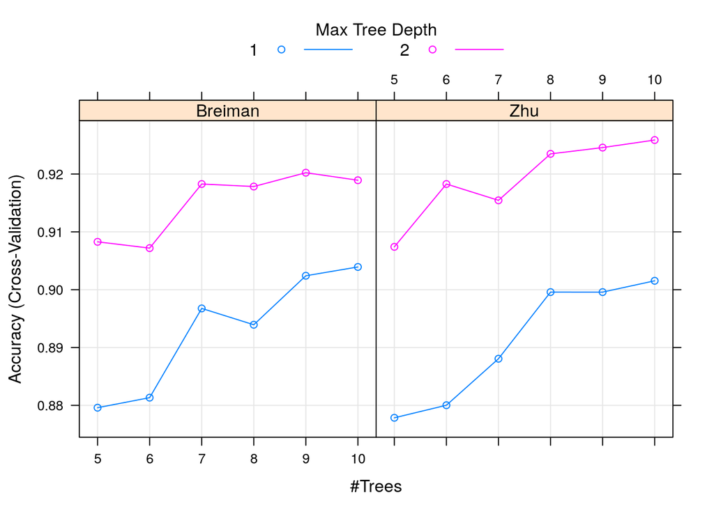

```r
plot(boost)
```

# 2 HMM

Como sabemos, en la composición del ADN intervienen 4 bases nitrogenadas: adenina (A), guanina (G), timina (T) y citosina (C). Supongamos que la generación de estas bases está regulada por una variable no observable S, con dos posibles estados, S<sub>1</sub> y S<sub>2</sub>. En la generación consecutiva de dos bases, la variable S permanece en el mismo estado en el 80% de los casos (ambos estados son igualmente probables inicialmente). Por otra parte, las probabilidades de generar las distintas bases en función del estado de la variable S aparecen recogidas en la siguiente tabla:

| Est. | A | G | T | C |
| --- | --- | --- | --- | --- |
| S<sub>1</sub> | 0.4 | 0.3 | 0.2 | 0.1 |
| S<sub>2</sub> | 0.1 | 0.1 | 0.3 | 0.5 |

1. Construya el modelo HMM correspondiente usando la librería HMM.
2. Calcule la probabilidad de obtener la siguiente secuencia: CGTCAGATA.
3. Dado que se ha observado la secuencia anterior, calcule la probabilidad de que la variable S se haya encontrado en cada uno de los dos estados posibles a lo largo de la generación de la secuencia (probabilidades a posteriori).
4. A partir de la secuencia observada, determine la secuencia de estados más probable para la variable S.
5. Genere una secuencia de longitud 100 mediante simulación.

## 2.1 Definición de modelo HMM

```r
library(HMM)
```

```r
Estados = c("S1","S2")
Observado = c("A","G","T","C")
ProbIni = c(0.5,0.5)
ProbTrans = matrix(c(0.8,0.2,0.2,0.8),nrow=2,byrow=T)
ProbEmis = matrix(c(0.4,0.3,0.2,0.1,0.1,0.1,0.3,0.5),nrow=2,byrow=T)

modHMM = initHMM(Estados,Observado,ProbIni,ProbTrans,ProbEmis)
print(modHMM)
```

```
## $States
## [1] "S1" "S2"
##
## $Symbols
## [1] "A" "G" "T" "C"
##
## $startProbs
##  S1  S2
## 0.5 0.5
##
## $transProbs
##     to
## from  S1  S2
##   S1 0.8 0.2
##   S2 0.2 0.8
##
## $emissionProbs
##       symbols
## states   A   G   T   C
##     S1 0.4 0.3 0.2 0.1
##     S2 0.1 0.1 0.3 0.5
```

## 2.2 Probabilidad de secuencia

```r
SecObs = c("C","G","T","C","A","G","A","T","A")

(Pforward = exp(forward(modHMM,SecObs)))
```

```
##       index
## states    1     2       3        4          5           6           7
##     S1 0.05 0.027 0.00516 0.000546 0.00042912 0.000118908 4.04352e-05
##     S2 0.25 0.021 0.00666 0.003180 0.00026532 0.000029808 4.76280e-06
##       index
## states            8            9
##     S1 6.660144e-06 2.416781e-06
##     S2 3.569184e-06 4.187376e-07
```

```r
(PSecObs = sum(Pforward[,9]))
```

```
## [1] 2.835518e-06
```

## 2.3 Probabilidades a posteori

```r
# Probabilidades a posteriori
(Pposterior = posterior(modHMM,SecObs))
```

```
##       index
## states         1        2         3         4         5          6
##     S1 0.2296266 0.458659 0.3626735 0.3375146 0.8097157 0.90244527
##     S2 0.7703734 0.541341 0.6373265 0.6624854 0.1902843 0.09755473
##       index
## states          7         8         9
##     S1 0.91265597 0.7986014 0.8523241
##     S2 0.08734403 0.2013986 0.1476759
```

## 2.4 Estados más probables

```r
# Estados más probables dada la secuencia
(Estados = viterbi(modHMM,SecObs))
```

```
## [1] "S2" "S2" "S2" "S2" "S1" "S1" "S1" "S1" "S1"
```

## 2.5 Simulación

```r
# Simulación
(sim = simHMM(modHMM,100))
```

```
## $states
##   [1] "S1" "S1" "S1" "S2" "S2" "S2" "S2" "S2" "S2" "S2" "S2" "S1" "S1" "S1"
##  [15] "S1" "S1" "S1" "S1" "S2" "S2" "S1" "S1" "S2" "S2" "S1" "S1" "S1" "S1"
##  [29] "S1" "S1" "S1" "S1" "S1" "S1" "S2" "S2" "S2" "S2" "S2" "S2" "S2" "S2"
##  [43] "S2" "S2" "S2" "S2" "S2" "S2" "S2" "S2" "S1" "S1" "S1" "S2" "S2" "S2"
##  [57] "S2" "S1" "S1" "S1" "S1" "S1" "S1" "S1" "S2" "S2" "S1" "S1" "S1" "S1"
##  [71] "S1" "S1" "S2" "S2" "S2" "S2" "S2" "S1" "S1" "S1" "S1" "S1" "S1" "S1"
##  [85] "S1" "S1" "S1" "S2" "S2" "S1" "S1" "S1" "S1" "S1" "S1" "S1" "S1" "S1"
##  [99] "S1" "S1"
##
## $observation
##   [1] "A" "G" "A" "T" "C" "C" "T" "C" "T" "T" "T" "G" "T" "A" "C" "C" "A"
##  [18] "A" "C" "T" "T" "A" "C" "T" "A" "T" "C" "G" "A" "C" "C" "T" "A" "C"
##  [35] "C" "G" "C" "C" "T" "C" "C" "C" "A" "C" "C" "A" "A" "C" "C" "C" "A"
##  [52] "A" "G" "T" "C" "C" "G" "G" "T" "G" "G" "G" "A" "G" "G" "T" "G" "G"
##  [69] "A" "G" "A" "T" "C" "T" "T" "C" "T" "G" "G" "A" "A" "T" "A" "G" "A"
##  [86] "A" "A" "C" "G" "A" "G" "G" "G" "A" "G" "G" "T" "G" "A" "C"
```

# 3 Filtrado

Realice las siguientes acciones sobre la base de datos *spam* de la librería *kernlab*:

1. Utilice los siguientes filtros univariantes de la librería *Fselector* para determinar los 10 atributos más relevantes en cada caso: chi-squared, gain.ratio, oneR, random.forest.importance, relief
2. Aplique el filtro multivariante CFS.
3. Aplique el filtro multivariante FCBF, utilizando un valor umbral 0.02 para la correlación del atributo con la variable de clase.
4. Indique cuáles son los 5 atributos más frecuentemente seleccionados por los procedimientos aplicados.

## 3.1 Filtros univariantes

```r
library(kernlab)
data(spam)
str(spam)
```

```
## 'data.frame':    4601 obs. of  58 variables:
##  $ make             : num  0 0.21 0.06 0 0 0 0 0 0.15 0.06 ...
##  $ address          : num  0.64 0.28 0 0 0 0 0 0 0 0.12 ...
##  $ all              : num  0.64 0.5 0.71 0 0 0 0 0 0.46 0.77 ...
##  $ num3d            : num  0 0 0 0 0 0 0 0 0 0 ...
##  $ our              : num  0.32 0.14 1.23 0.63 0.63 1.85 1.92 1.88 0.61 0.19 ...
##  $ over             : num  0 0.28 0.19 0 0 0 0 0 0 0.32 ...
##  $ remove           : num  0 0.21 0.19 0.31 0.31 0 0 0 0.3 0.38 ...
##  $ internet         : num  0 0.07 0.12 0.63 0.63 1.85 0 1.88 0 0 ...
##  $ order            : num  0 0 0.64 0.31 0.31 0 0 0 0.92 0.06 ...
##  $ mail             : num  0 0.94 0.25 0.63 0.63 0 0.64 0 0.76 0 ...
##  $ receive          : num  0 0.21 0.38 0.31 0.31 0 0.96 0 0.76 0 ...
##  $ will             : num  0.64 0.79 0.45 0.31 0.31 0 1.28 0 0.92 0.64 ...
##  $ people           : num  0 0.65 0.12 0.31 0.31 0 0 0 0 0.25 ...
##  $ report           : num  0 0.21 0 0 0 0 0 0 0 0 ...
```

[output cut: 44 more lines]

```r
library(FSelector)
```

### 3.1.1 Chi-squared

```r
chi.w = chi.squared(type~.,spam)
cutoff.k(chi.w,10)
```

```
##  [1] "charExclamation" "charDollar"      "capitalLong"
##  [4] "your"            "remove"          "capitalAve"
##  [7] "free"            "money"           "capitalTotal"
## [10] "num000"
```

```r
chi.w[cutoff.k(chi.w,10),]
```

```
##  [1] 0.6024238 0.5834606 0.5339708 0.5246459 0.5216294 0.5059197 0.5046953
##  [8] 0.4751467 0.4493644 0.4298761
```

```r
resumen = cutoff.k(chi.w,10)
```

### 3.1.2 Gain-ratio

```r
gain.w=gain.ratio(type~.,spam)
cutoff.k(gain.w,10)
```

```
##  [1] "remove"          "money"           "num000"
##  [4] "free"            "charDollar"      "credit"
##  [7] "hpl"             "george"          "charExclamation"
## [10] "receive"
```

```r
gain.w[cutoff.k(gain.w,10),]
```

```
##  [1] 0.3183780 0.2743965 0.2309961 0.2279615 0.1997369 0.1923899 0.1713143
##  [8] 0.1663031 0.1625829 0.1565212
```

```r
resumen = append(resumen,cutoff.k(gain.w,10))
```

### 3.1.3 OneR

```r
oneR.w=oneR(type~.,spam)
cutoff.k(oneR.w,10)
```

```
##  [1] "remove"  "money"   "parts"   "table"   "cs"      "meeting" "direct"
##  [8] "num857"  "lab"     "telnet"
```

```r
oneR.w[cutoff.k(oneR.w,10),]
```

```
##  [1] 1.565493 1.528987 1.501221 1.501221 1.481592 1.478962 1.474467
##  [8] 1.473544 1.466798 1.464878
```

```r
resumen = append(resumen,cutoff.k(oneR.w,10))
```

### 3.1.4 Random Forest

```r
rF.w=random.forest.importance(type~.,spam)
cutoff.k(rF.w,10)
```

```
##  [1] "charExclamation" "remove"          "capitalAve"
##  [4] "hp"              "charDollar"      "capitalLong"
##  [7] "edu"             "free"            "capitalTotal"
## [10] "your"
```

```r
rF.w[cutoff.k(rF.w,10),]
```

```
##  [1] 72.17591 64.43949 59.86123 58.79170 55.98540 54.72040 53.37630
##  [8] 52.71486 46.15675 43.08736
```

```r
resumen = append(resumen,cutoff.k(rF.w,10))
```

### 3.1.5 Relief

```r
relief.w=relief(type~.,spam)
cutoff.k(relief.w,10)
```

```
##  [1] "george"       "meeting"      "hp"           "pm"
##  [5] "direct"       "will"         "capitalTotal" "business"
##  [9] "technology"   "all"
```

```r
relief.w[cutoff.k(relief.w,10),]
```

```
##  [1] 0.06689469 0.04390756 0.02838214 0.02531053 0.02252101 0.02126163
##  [7] 0.01807828 0.01549020 0.01461638 0.01431373
```

```r
resumen = append(resumen, cutoff.k(relief.w,10))
```

## 3.2 Filtro multivariante CFS

```r
cfs.w = cfs(type~.,spam)
cfs.w
```

```
##  [1] "remove"          "free"            "your"
##  [4] "num000"          "money"           "hp"
##  [7] "george"          "charExclamation" "charDollar"
## [10] "capitalAve"
```

```r
resumen = append(resumen,cfs.w)
```

## 3.3 Filtro multivariante FCBF

```r
library(Biocomb)
fcbf = select.fast.filter(spam,disc.method="MDL",threshold=0.02,attrs.nominal=numeric())
fcbf
```

```
##          Biomarker Information.Gain NumberFeature
## 1  charExclamation       0.19444917            52
## 2       charDollar       0.18110529            53
## 3      capitalLong       0.15942948            56
## 4           remove       0.14783596             7
## 5             your       0.14345068            21
## 6             free       0.12983756            16
## 7               hp       0.10703484            25
## 8           george       0.08856656            27
## 9              edu       0.03566742            46
## 10         meeting       0.02775998            42
```

```r
resumen = append(resumen, as.character(fcbf[,1]))
```

## 3.4 Resumen atributos más frecuentes

```r
resumen
```

```
##  [1] "charExclamation" "charDollar"      "capitalLong"
##  [4] "your"            "remove"          "capitalAve"
##  [7] "free"            "money"           "capitalTotal"
## [10] "num000"          "remove"          "money"
## [13] "num000"          "free"            "charDollar"
## [16] "credit"          "hpl"             "george"
## [19] "charExclamation" "receive"         "remove"
## [22] "money"           "parts"           "table"
## [25] "cs"              "meeting"         "direct"
## [28] "num857"          "lab"             "telnet"
## [31] "charExclamation" "remove"          "capitalAve"
## [34] "hp"              "charDollar"      "capitalLong"
## [37] "edu"             "free"            "capitalTotal"
## [40] "your"            "george"          "meeting"
## [43] "hp"              "pm"              "direct"
## [46] "will"            "capitalTotal"    "business"
## [49] "technology"      "all"             "remove"
## [52] "free"            "your"            "num000"
## [55] "money"           "hp"              "george"
## [58] "charExclamation" "charDollar"      "capitalAve"
## [61] "charExclamation" "charDollar"      "capitalLong"
## [64] "remove"          "your"            "free"
## [67] "hp"              "george"          "edu"
## [70] "meeting"
```

```r
resumen.freq= as.matrix(table(resumen))
resumen.freq[order(resumen.freq,decreasing = TRUE),]
```

```
##          remove      charDollar charExclamation            free
##               6               5               5               5
##          george              hp           money            your
##               4               4               4               4
##      capitalAve     capitalLong    capitalTotal         meeting
##               3               3               3               3
##          num000          direct             edu             all
##               3               2               2               1
##        business          credit              cs             hpl
##               1               1               1               1
##             lab          num857           parts              pm
##               1               1               1               1
##         receive           table      technology          telnet
##               1               1               1               1
##            will
##               1
```

```r
cutoff.k(resumen.freq, 5)
```

```
## [1] "remove"          "charDollar"      "charExclamation" "free"
## [5] "george"
```